# pratical-machine-learning-project

Fabio Bianchini

4/12/2020

##### Read Human Activity Recognition - HAR - training and test dataset

```r
# Read training dataset
HAR_training <- read.csv(file="https://d396qusza40orc.cloudfront.net/predmachlearn/pml-training.csv", header=TRUE,sep=",")
dim(HAR_training)
```

```
## [1] 19622   160
```

```r
# Read test dataset
HAR_testing <- read.csv(file="https://d396qusza40orc.cloudfront.net/predmachlearn/pml-testing.csv", header=TRUE,sep=",")
dim(HAR_testing)
```

```
## [1]  20 160
```

##### Determine the data types of a data frame’s columns

Now let’s do an exploratory analysis of the datasets to verify the content and type of predictor variables present

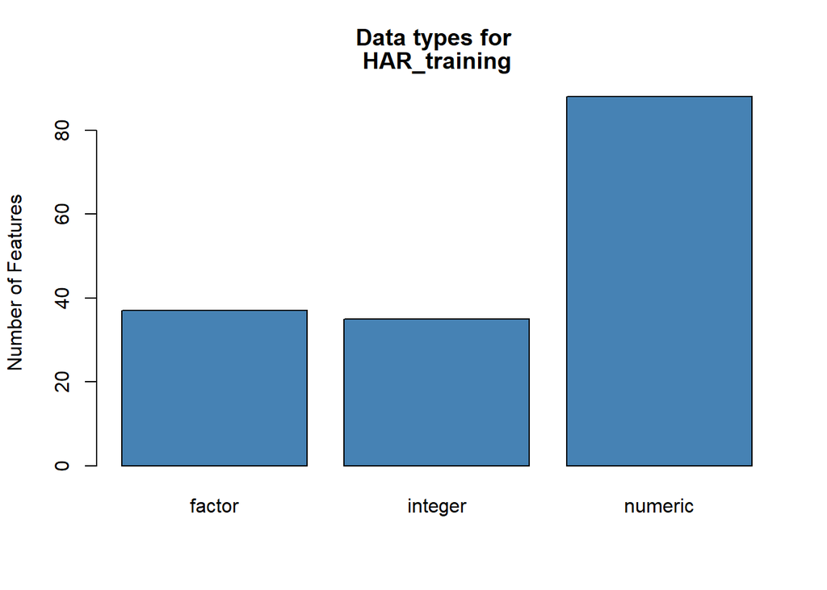

```r
#
data_types <- function(frame) {
  res <- lapply(frame, class)
  res_frame <- data.frame(unlist(res))
#  View(res_frame)
  dataset_name <- deparse(substitute(frame))
  barplot(table(res_frame), main=c("Data types for ", dataset_name), col="steelblue", ylab="Number of Features")
}
#par(mfrow=c(2,1))
data_types(HAR_training)
```

```r
table(unlist(lapply(HAR_training, class)))
```

```
##
##  factor integer numeric
##      37      35      88
```

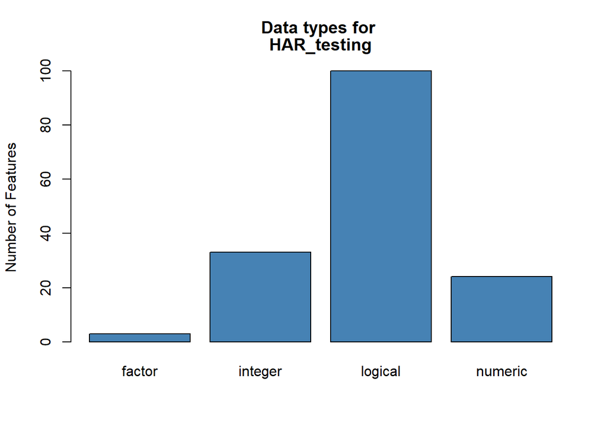

```r
#
data_types(HAR_testing)
```

```r
table(unlist(lapply(HAR_testing, class)))
```

```
##
##  factor integer logical numeric
##       3      33     100      24
```

```r
#
```

##### Cleaning the input data

Now let’s clean up and rearrange the datasets

```r
all_na <- function(x) any(is.na(x))
# We remove the variables that contains missing value
train_col_na <- HAR_training %>% select_if(all_na)
# remove from training dataset
new_train <-select(HAR_training, -c(names(train_col_na)))
dim(new_train)
```

```
## [1] 19622    93
```

```r
# remove from testing dataset
test_col_na <- HAR_testing %>% select_if(all_na)
new_test <- select(HAR_testing, -c(names(test_col_na)))
dim(new_test)
```

```
## [1] 20 60
```

… and remove the first seven variables as they have little impact on the outcome “*classe*”

```r
View(HAR_training[1:5, c(1:7)])
new_train <- new_train[, -c(1:7)]
dim(new_train)
```

```
## [1] 19622    86
```

```r
View(HAR_testing[1:5, c(1:7)])
new_test <- new_test[, -c(1:7)]
dim(new_test)
```

```
## [1] 20 53
```

##### Data preparation for Prediction

now split the traning data…

```r
set.seed(1234)
inTrain <- createDataPartition(new_train$classe, p = 0.7, list = FALSE)
# Create the training dataset
ds_training <- new_train[inTrain, ]
dim(ds_training)
```

```
## [1] 13737    86
```

```r
# Create the validation dataset
ds_validation <- new_train[-inTrain, ]
dim(ds_validation)
```

```
## [1] 5885   86
```

Remove the “*near zero-variance predictor*” from the datasets

```r
nzv <- nearZeroVar(ds_training)
ds_training <- ds_training[,-nzv]
dim(ds_training)
```

```
## [1] 13737    53
```

```r
ds_validation <- ds_validation[,-nzv]
dim(ds_validation)
```

```
## [1] 5885   53
```

and *minimize the multicollateral effect* by removing the redundant features

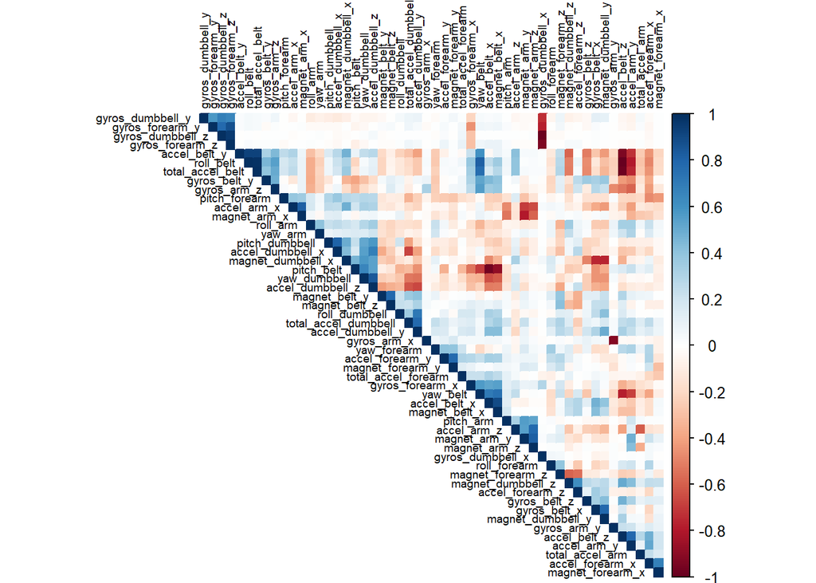

```r
### Compute the correlation matrix of the predictor
# Remove factor variable from HAR_training dataset
descrCorr <- cor(ds_training[,-53], use = "pairwise.complete.obs")
# Show correlation matrix
corr_image <- corrplot(descrCorr, tl.col = "black",  method = "color",tl.cex = 0.6, type = "upper", order = "hclust")
```

```r
# find attributes that are highly corrected
highCorr <- findCorrelation(descrCorr,cutoff =  0.75)
names(ds_training)[highCorr]
```

```
##  [1] "accel_belt_z"      "roll_belt"         "accel_belt_y"
##  [4] "total_accel_belt"  "accel_dumbbell_z"  "accel_belt_x"
##  [7] "pitch_belt"        "magnet_dumbbell_x" "accel_dumbbell_y"
## [10] "magnet_dumbbell_y" "accel_dumbbell_x"  "accel_arm_x"
## [13] "accel_arm_z"       "magnet_arm_y"      "magnet_belt_z"
## [16] "accel_forearm_y"   "gyros_forearm_y"   "gyros_dumbbell_x"
## [19] "gyros_dumbbell_z"  "gyros_arm_x"
```

```r
# Remove the high correlate colon from the training dataset
ds_training <- ds_training[,-highCorr]
dim(ds_training)
```

```
## [1] 13737    33
```

```r
ds_validation <- ds_validation[,-highCorr]
dim(ds_validation)
```

```
## [1] 5885   33
```

#### Building and tuning models

We will apply this classification Models to the traning dataset

- KNN Model
- SVM Model
- Random Forest Model

##### K-nearest neighbors Model

```r
set.seed(1234)
trainCtrl_knn <- trainControl(method = "repeatedcv", number = 5, repeats = 1)
modelfit_knn <- train(classe ~ ., data = ds_training, method="knn", trControl = trainCtrl_knn)
#
modelfit_knn
```

```
## k-Nearest Neighbors
##
## 13737 samples
##    32 predictor
##     5 classes: 'A', 'B', 'C', 'D', 'E'
##
## No pre-processing
## Resampling: Cross-Validated (5 fold, repeated 1 times)
## Summary of sample sizes: 10990, 10991, 10988, 10990, 10989
## Resampling results across tuning parameters:
##
##   k  Accuracy   Kappa
##   5  0.8394102  0.7969579
##   7  0.8148052  0.7657889
##   9  0.7978439  0.7443060
##
## Accuracy was used to select the optimal model using the largest value.
## The final value used for the model was k = 5.
```

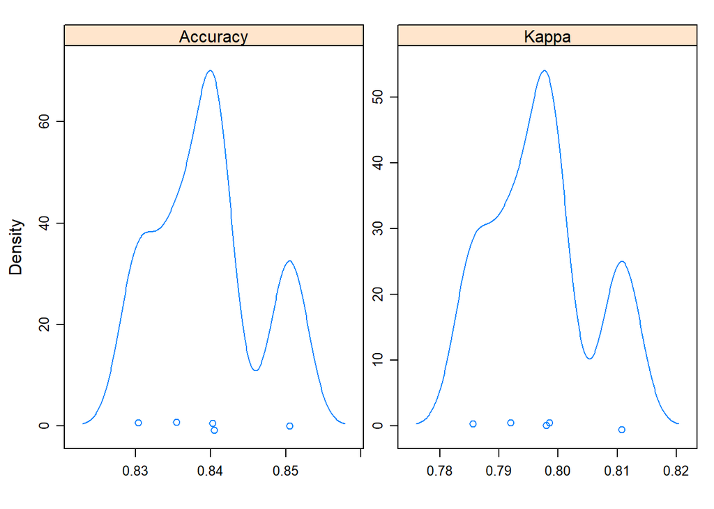

```r
resampleHist((modelfit_knn))
```

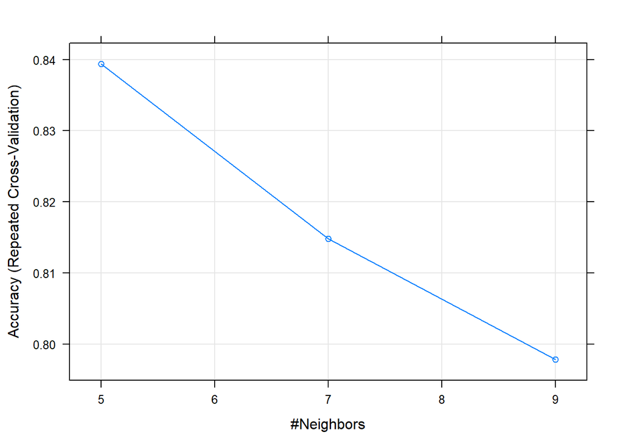

```r
plot(modelfit_knn)
```

```r
#
predict_knn <- predict(modelfit_knn, newdata = ds_validation, na.action = na.pass)
#
cm_knn <- confusionMatrix(predict_knn, ds_validation$classe)
cm_knn
```

```
## Confusion Matrix and Statistics
##
##           Reference
## Prediction    A    B    C    D    E
##          A 1562   57   14   19   23
##          B   29  925   47   20   57
##          C   18   52  911   88   54
##          D   50   43   40  802   55
##          E   15   62   14   35  893
##
## Overall Statistics
##
##                Accuracy : 0.8654
##                  95% CI : (0.8564, 0.874)
##     No Information Rate : 0.2845
##     P-Value [Acc > NIR] : < 2.2e-16
##
##                   Kappa : 0.8298
##
##  Mcnemar's Test P-Value : 4.883e-13
##
## Statistics by Class:
##
##                      Class: A Class: B Class: C Class: D Class: E
## Sensitivity            0.9331   0.8121   0.8879   0.8320   0.8253
## Specificity            0.9732   0.9678   0.9564   0.9618   0.9738
## Pos Pred Value         0.9325   0.8581   0.8112   0.8101   0.8763
## Neg Pred Value         0.9734   0.9555   0.9759   0.9669   0.9612
## Prevalence             0.2845   0.1935   0.1743   0.1638   0.1839
## Detection Rate         0.2654   0.1572   0.1548   0.1363   0.1517
## Detection Prevalence   0.2846   0.1832   0.1908   0.1682   0.1732
## Balanced Accuracy      0.9531   0.8899   0.9221   0.8969   0.8995
```

We see that the accuracy rate of the model is *Accuracy: 0.8654* and therefore *the out-of-sample-error is about 0.1346*.

##### SVM Model

```r
set.seed(1234)
trainCtrl_svm <- trainControl(method = "repeatedcv", number = 5, repeats = 1)
modelfit_svm <- train(classe ~ ., data = ds_training, method="svmRadial", trControl = trainCtrl_svm, preProcess = c("center","scale"), tuneLength = 10)
# tuneGrid = expand.grid(C = seq(0.1, 2, length = 20))
modelfit_svm
```

```
## Support Vector Machines with Radial Basis Function Kernel
##
## 13737 samples
##    32 predictor
##     5 classes: 'A', 'B', 'C', 'D', 'E'
##
## Pre-processing: centered (32), scaled (32)
## Resampling: Cross-Validated (5 fold, repeated 1 times)
## Summary of sample sizes: 10990, 10991, 10988, 10990, 10989
## Resampling results across tuning parameters:
##
##   C       Accuracy   Kappa
##     0.25  0.8436352  0.8017557
##     0.50  0.8802517  0.8481480
##     1.00  0.9106802  0.8867697
##     2.00  0.9347759  0.9173496
##     4.00  0.9553771  0.9434804
##     8.00  0.9692076  0.9610169
##    16.00  0.9759770  0.9695962
##    32.00  0.9828926  0.9783531
##    64.00  0.9874787  0.9841586
##   128.00  0.9893709  0.9865541
##
## Tuning parameter 'sigma' was held constant at a value of 0.02105038
## Accuracy was used to select the optimal model using the largest value.
## The final values used for the model were sigma = 0.02105038 and C = 128.
```

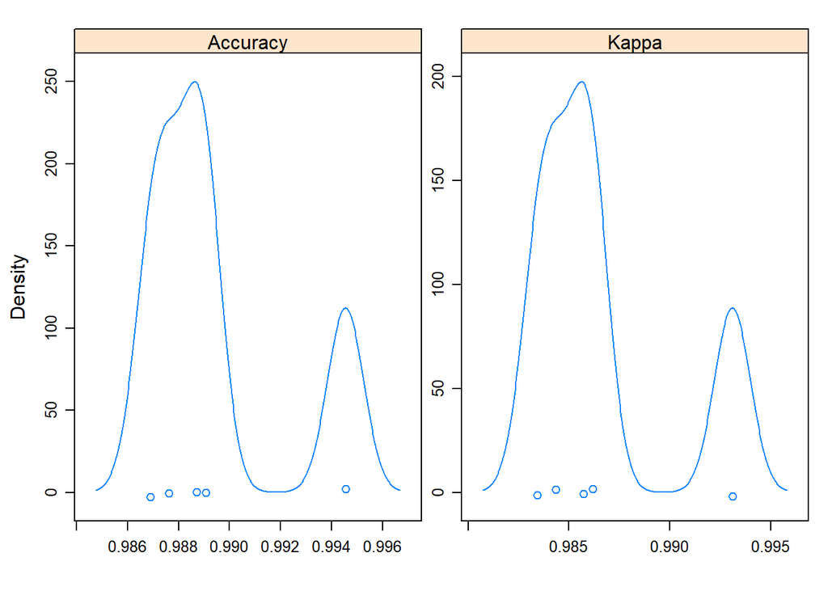

```r
resampleHist((modelfit_svm))
```

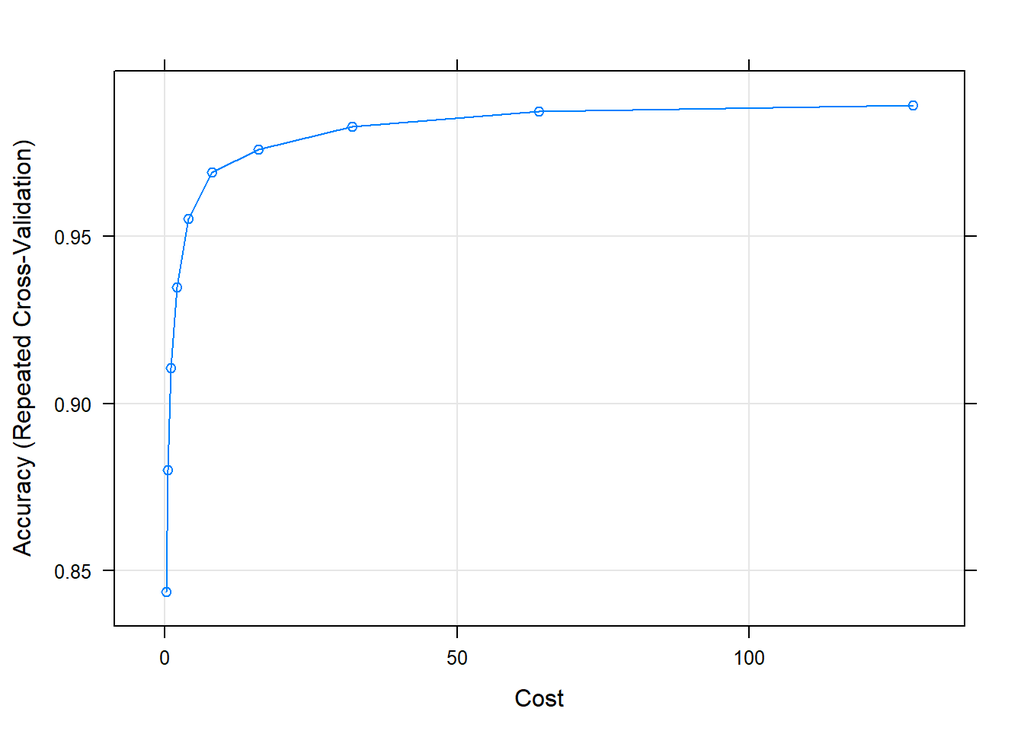

```r
plot(modelfit_svm)
```

```r
#
predict_svm <- predict(modelfit_svm, newdata = ds_validation, na.action = na.pass)
#
cm_svm <- confusionMatrix(predict_svm, ds_validation$classe)
cm_svm
```

```
## Confusion Matrix and Statistics
##
##           Reference
## Prediction    A    B    C    D    E
##          A 1668    3    0    3    0
##          B    5 1128    5    0    0
##          C    1    6 1013   25    0
##          D    0    2    8  934    0
##          E    0    0    0    2 1082
##
## Overall Statistics
##
##                Accuracy : 0.9898
##                  95% CI : (0.9869, 0.9922)
##     No Information Rate : 0.2845
##     P-Value [Acc > NIR] : < 2.2e-16
##
##                   Kappa : 0.9871
##
##  Mcnemar's Test P-Value : NA
##
## Statistics by Class:
##
##                      Class: A Class: B Class: C Class: D Class: E
## Sensitivity            0.9964   0.9903   0.9873   0.9689   1.0000
## Specificity            0.9986   0.9979   0.9934   0.9980   0.9996
## Pos Pred Value         0.9964   0.9912   0.9694   0.9894   0.9982
## Neg Pred Value         0.9986   0.9977   0.9973   0.9939   1.0000
## Prevalence             0.2845   0.1935   0.1743   0.1638   0.1839
## Detection Rate         0.2834   0.1917   0.1721   0.1587   0.1839
## Detection Prevalence   0.2845   0.1934   0.1776   0.1604   0.1842
## Balanced Accuracy      0.9975   0.9941   0.9904   0.9834   0.9998
```

We see that the accuracy rate of the model is *Accuracy: 0.9898* and therefore *the out-of-sample-error is about 0.0102*.

##### Prediction with Random Forest method

```r
set.seed(12345)
trainCtrl <- trainControl(method = "cv", number = 5, verboseIter = FALSE)
modelfit_rf <- train(classe ~ ., data = ds_training, method="rf", trControl = trainCtrl)
modelfit_rf
```

```
## Random Forest
##
## 13737 samples
##    32 predictor
##     5 classes: 'A', 'B', 'C', 'D', 'E'
##
## No pre-processing
## Resampling: Cross-Validated (5 fold)
## Summary of sample sizes: 10990, 10990, 10989, 10991, 10988
## Resampling results across tuning parameters:
##
##   mtry  Accuracy   Kappa
##    2    0.9902453  0.9876592
##   17    0.9891539  0.9862798
##   32    0.9812917  0.9763333
##
## Accuracy was used to select the optimal model using the largest value.
## The final value used for the model was mtry = 2.
```

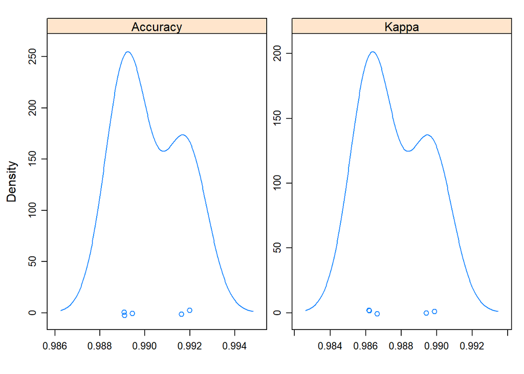

```r
resampleHist((modelfit_rf))
```

```r
#
predict_rf <- predict(modelfit_rf, newdata = ds_validation, na.action = na.pass)
#
cm_rf <- confusionMatrix(predict_rf, ds_validation$classe)
cm_rf
```

```
## Confusion Matrix and Statistics
##
##           Reference
## Prediction    A    B    C    D    E
##          A 1673    1    0    1    0
##          B    1 1130   12    0    0
##          C    0    8 1011   15    0
##          D    0    0    3  947    0
##          E    0    0    0    1 1082
##
## Overall Statistics
##
##                Accuracy : 0.9929
##                  95% CI : (0.9904, 0.9949)
##     No Information Rate : 0.2845
##     P-Value [Acc > NIR] : < 2.2e-16
##
##                   Kappa : 0.991
##
##  Mcnemar's Test P-Value : NA
##
## Statistics by Class:
##
##                      Class: A Class: B Class: C Class: D Class: E
## Sensitivity            0.9994   0.9921   0.9854   0.9824   1.0000
## Specificity            0.9995   0.9973   0.9953   0.9994   0.9998
## Pos Pred Value         0.9988   0.9886   0.9778   0.9968   0.9991
## Neg Pred Value         0.9998   0.9981   0.9969   0.9966   1.0000
## Prevalence             0.2845   0.1935   0.1743   0.1638   0.1839
## Detection Rate         0.2843   0.1920   0.1718   0.1609   0.1839
## Detection Prevalence   0.2846   0.1942   0.1757   0.1614   0.1840
## Balanced Accuracy      0.9995   0.9947   0.9903   0.9909   0.9999
```

The accuracy rate using the random forest is very high: *Accuracy : 0.9929* and therefore the *out-of-sample-error is equal to 0.0071*

##### Do predictions with the and compare the models

the random forest model is the one with the best accuracy and therefore will be used to predict the new values

```r
Results_rt <- predict(modelfit_rf, newdata=new_test)
Results_rt
```

```
##  [1] B A B A A E D B A A B C B A E E A B B B
## Levels: A B C D E
```